# Module 07: Social Network Analysis

Computational Social Science — Graduate & Undergraduate

2026-04-04

# 1 Overview

Social life is relational. People do not exist as isolated atoms, each carrying fixed characteristics that add up to social outcomes. They are embedded in webs of relationships — friendship, kinship, collaboration, conflict, communication — and those relational positions shape their access to resources, their exposure to information, their susceptibility to influence, and their life chances.

Network analysis is the set of methods that takes this relational structure seriously. Instead of asking “what characteristics predict outcome Y?”, it asks: “how does a person’s position in a network shape their outcomes, and what determines who is connected to whom?”

**Learning goals:**

- Represent social networks as graph objects and understand the basic vocabulary
- Compute and interpret standard network statistics (density, clustering, path length)
- Compute all major centrality measures and understand what each captures
- Detect community structure using multiple algorithms
- Visualise networks informatively
- Fit and interpret an Exponential Random Graph Model (ERGM)
- Read the full ERGM output section by section

# 2 Part A: Graph Theory Fundamentals

## 2.1 Representing a Network

A **graph** G = (V, E) consists of a set of **nodes** (vertices) V and a set of **edges** (ties) E connecting pairs of nodes. In social science:

- **Nodes** are social actors: people, organisations, countries, texts, events
- **Edges** are relationships: friendships, citations, trade flows, communications, co-occurrences

Networks can be:

| Type | Description | Example |
| --- | --- | --- |
| **Undirected** | Edge has no direction; A–B = B–A | Facebook friendship |
| **Directed** | Edge has direction; A→B ≠ B→A | Twitter follow, email sent |
| **Weighted** | Edges have a numerical strength | Number of emails sent |
| **Bipartite** | Two types of nodes; edges only cross types | People × organisations |
| **Multiplex** | Multiple types of edges between same nodes | Friends who are also colleagues |

## 2.2 Building a Network from Scratch

```r
library(igraph)
library(tidygraph)
library(ggraph)

# Method 1: From an edge list (most common in practice)
# Each row = one edge: (from, to)
edge_list <- tribble(
  ~from, ~to,
  "Alice",  "Bob",
  "Alice",  "Carol",
  "Alice",  "Dan",
  "Bob",    "Carol",
  "Bob",    "Eve",
  "Carol",  "Frank",
  "Dan",    "Eve",
  "Eve",    "Frank",
  "Frank",  "Grace",
  "Grace",  "Alice"   # creates a cycle
)

g <- graph_from_data_frame(edge_list, directed=FALSE)

cat("=== Network Summary ===\n")
```

```
## === Network Summary ===
```

```r
cat("Number of nodes (V):", vcount(g), "\n")
```

```
## Number of nodes (V): 7
```

```r
cat("Number of edges (E):", ecount(g), "\n")
```

```
## Number of edges (E): 10
```

```r
cat("Node names:", paste(V(g)$name, collapse=", "), "\n\n")
```

```
## Node names: Alice, Bob, Carol, Dan, Eve, Frank, Grace
```

```r
# Method 2: From an adjacency matrix
# Row i, column j = 1 if i and j are connected; 0 otherwise
adj_mat <- matrix(c(
  0,1,1,0,
  1,0,1,1,
  1,1,0,0,
  0,1,0,0
), nrow=4, byrow=TRUE,
dimnames=list(c("A","B","C","D"), c("A","B","C","D")))

cat("Adjacency matrix (alternative input format):\n")
```

```
## Adjacency matrix (alternative input format):
```

```r
print(adj_mat)
```

```
##   A B C D
## A 0 1 1 0
## B 1 0 1 1
## C 1 1 0 0
## D 0 1 0 0
```

```r
g2 <- graph_from_adjacency_matrix(adj_mat, mode="undirected")
cat("\nGraph from adjacency matrix: V =", vcount(g2), "E =", ecount(g2), "\n")
```

```
##
## Graph from adjacency matrix: V = 4 E = 4
```

## 2.3 Basic Network Statistics

Before computing centrality, understand the network’s overall structure:

```r
cat("=== STANDARD NETWORK STATISTICS ===\n\n")
```

```
## === STANDARD NETWORK STATISTICS ===
```

```r
# 1. Density: proportion of possible edges that exist
# Range: 0 (no edges) to 1 (every pair connected)
# Formula: 2E / (V*(V-1)) for undirected; E / (V*(V-1)) for directed
dens <- edge_density(g)
cat("1. Density:", round(dens, 3), "\n")
```

```
## 1. Density: 0.476
```

```r
cat("   Interpretation: ", round(dens*100, 1),
    "% of all possible edges are present.\n")
```

```
##    Interpretation:  47.6 % of all possible edges are present.
```

```r
cat("   Context: Real social networks: 0.01–0.15 is typical.\n",
    "   Dense (> 0.5): small, tight-knit groups.\n",
    "   Sparse (< 0.05): large networks where most pairs are unconnected.\n\n")
```

```
##    Context: Real social networks: 0.01–0.15 is typical.
##     Dense (> 0.5): small, tight-knit groups.
##     Sparse (< 0.05): large networks where most pairs are unconnected.
```

```r
# 2. Average path length: average number of steps between any two reachable nodes
apl <- mean_distance(g, directed=FALSE)
cat("2. Average path length:", round(apl, 3), "\n")
```

```
## 2. Average path length: 1.524
```

```r
cat("   Interpretation: On average,", round(apl, 1),
    "steps separate any two nodes.\n")
```

```
##    Interpretation: On average, 1.5 steps separate any two nodes.
```

```r
cat("   This network is", ifelse(apl < 3, "'small world'",
    ifelse(apl < 6, "moderately connected", "loosely connected")), ".\n\n")
```

```
##    This network is 'small world' .
```

```r
# 3. Diameter: the longest shortest path in the network
diam <- diameter(g, directed=FALSE)
cat("3. Diameter:", diam, "\n")
```

```
## 3. Diameter: 2
```

```r
cat("   Interpretation: The most distant pair of nodes is", diam,
    "steps apart.\n\n")
```

```
##    Interpretation: The most distant pair of nodes is 2 steps apart.
```

```r
# 4. Clustering coefficient (transitivity): P(A-B and B-C → A-C)
# = proportion of open triads that are closed triangles
trans <- transitivity(g, type="global")
cat("4. Global clustering coefficient (transitivity):", round(trans, 3), "\n")
```

```
## 4. Global clustering coefficient (transitivity): 0.15
```

```r
cat("   Interpretation:", round(trans*100, 1),
    "% of connected triples form a closed triangle.\n")
```

```
##    Interpretation: 15 % of connected triples form a closed triangle.
```

```r
cat("   High transitivity = 'friends of friends are friends' pattern.\n")
```

```
##    High transitivity = 'friends of friends are friends' pattern.
```

```r
cat("   Typical social networks: 0.3–0.6. Random graphs: near 0.\n\n")
```

```
##    Typical social networks: 0.3–0.6. Random graphs: near 0.
```

```r
# 5. Components: is the network fully connected?
comps <- components(g)
cat("5. Connected components:", comps$no, "\n")
```

```
## 5. Connected components: 1
```

```r
cat("   Largest component:", max(comps$csize), "nodes (",
    round(max(comps$csize)/vcount(g)*100, 1), "% of all nodes)\n")
```

```
##    Largest component: 7 nodes ( 100 % of all nodes)
```

```r
cat("   If components > 1: some nodes cannot reach others — important for\n",
    "   diffusion and information flow analyses.\n")
```

```
##    If components > 1: some nodes cannot reach others — important for
##     diffusion and information flow analyses.
```

**What these statistics tell you, together:**

## 2.4 Visualising the Network

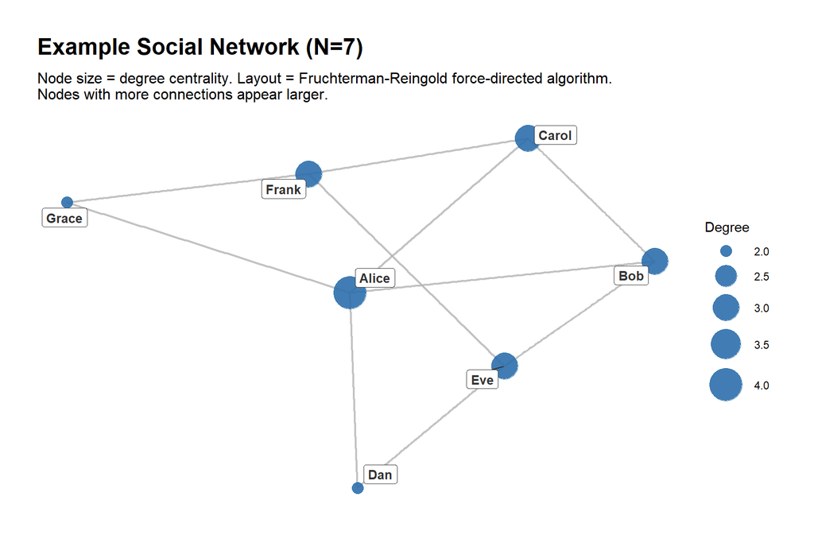

```r
# Convert to tidygraph for ggraph plotting
tg <- as_tbl_graph(g) |>
  mutate(degree = centrality_degree())

ggraph(tg, layout="fr") +   # Fruchterman-Reingold layout
  geom_edge_link(colour="grey70", linewidth=0.8, alpha=0.8) +
  geom_node_point(aes(size=degree), colour="#2C6FAC", alpha=0.9) +
  geom_node_label(aes(label=name), repel=TRUE, size=3.5,
                  fontface="bold", colour="grey20") +
  scale_size_continuous(range=c(4,12), name="Degree") +
  labs(
    title    = "Example Social Network (N=7)",
    subtitle = paste("Node size = degree centrality.",
                     "Layout = Fruchterman-Reingold force-directed algorithm.",
                     "\nNodes with more connections appear larger.")
  ) +
  theme_graph(base_family="")
```

**Choosing a layout algorithm:**

| Layout | Best For | How It Works |
| --- | --- | --- |
| `fr` (Fruchterman-Reingold) | General purpose; medium networks | Treats edges as springs; nodes repel each other |
| `kk` (Kamada-Kawai) | Emphasising path distances | Positions nodes to reflect their graph-theoretic distances |
| `circle` | Small networks; comparing structure | Nodes on a circle; no spatial meaning |
| `tree` | Hierarchical (parent-child) structures | Top-down tree arrangement |
| `bipartite` | Two-mode (bipartite) networks | Separates two node types into rows |

# 3 Part B: Centrality Measures

## 3.1 What Centrality Captures

“Centrality” is a family of measures, each capturing a different aspect of structural importance. They can give very different rankings for the same node. Always ask: centrality in what sense, for what process?

```r
# Use a larger, more interesting network — the Zachary karate club
# Classic benchmark: 34 members, split into two factions due to a dispute
data("karate", package="igraphdata")

cat("=== Zachary Karate Club Network ===\n")
```

```
## === Zachary Karate Club Network ===
```

```r
cat("Nodes:", vcount(karate), "club members\n")
```

```
## Nodes: 34 club members
```

```r
cat("Edges:", ecount(karate), "pairs who socialised outside the club\n")
```

```
## Edges: 78 pairs who socialised outside the club
```

```r
cat("Historical note: The club split into two factions around nodes 1 and 34.\n\n")
```

```
## Historical note: The club split into two factions around nodes 1 and 34.
```

```r
# Compute all four major centrality measures
cent_df <- tibble(
  Node        = V(karate)$name,
  Degree      = degree(karate),
  Betweenness = round(betweenness(karate, normalized=TRUE), 4),
  Closeness   = round(closeness(karate, normalized=TRUE), 4),
  Eigenvector = round(eigen_centrality(karate)$vector, 4)
)

cat("Top 10 nodes by each centrality measure:\n\n")
```

[output not shown]

```r
for (measure in c("Degree","Betweenness","Closeness","Eigenvector")) {
  cat(measure, "top 5:", paste(
    cent_df |> arrange(desc(.data[[measure]])) |> head(5) |> pull(Node),
    collapse=", "), "\n")
}
```

```
## Degree top 5: John A, Mr Hi, Actor 33, Actor 3, Actor 2
## Betweenness top 5: Mr Hi, John A, Actor 20, Actor 32, Actor 33
## Closeness top 5: Mr Hi, John A, Actor 20, Actor 32, Actor 13
## Eigenvector top 5: John A, Actor 3, Actor 33, Mr Hi, Actor 2
```

```r
cent_df |>
  arrange(desc(Degree)) |>
  head(12) |>
  kbl(caption="Centrality Measures — Karate Club Network (Top 12 by Degree)",
      digits=4) |>
  kable_styling(bootstrap_options=c("striped","hover","condensed")) |>
  footnote(general=paste(
    "Degree = number of connections (raw count).",
    "Betweenness = proportion of shortest paths passing through this node (0–1).",
    "\nCloseness = how quickly this node can reach all others (0–1).",
    "Eigenvector = influence via connections to influential others (0–1)."
  ))
```

Centrality Measures — Karate Club Network (Top 12 by Degree)

| Node | Degree | Betweenness | Closeness | Eigenvector |
| --- | --- | --- | --- | --- |
| John A | 17 | 0.3968 | 0.2519 | 1.0000 |
| Mr Hi | 16 | 0.4738 | 0.2538 | 0.8579 |
| Actor 33 | 12 | 0.0722 | 0.2000 | 0.9126 |
| Actor 3 | 10 | 0.0694 | 0.1964 | 0.9904 |
| Actor 2 | 9 | 0.0640 | 0.2000 | 0.8288 |
| Actor 4 | 6 | 0.0025 | 0.1765 | 0.5454 |
| Actor 32 | 6 | 0.1256 | 0.2089 | 0.5753 |
| Actor 9 | 5 | 0.0248 | 0.1988 | 0.6783 |
| Actor 14 | 5 | 0.0023 | 0.1908 | 0.6605 |
| Actor 24 | 5 | 0.0019 | 0.1387 | 0.5989 |
| Actor 6 | 4 | 0.0294 | 0.1521 | 0.1852 |
| Actor 7 | 4 | 0.0294 | 0.1535 | 0.1825 |

Note:  
Degree = number of connections (raw count). Betweenness = proportion of shortest paths passing through this node (0–1). Closeness = how quickly this node can reach all others (0–1). Eigenvector = influence via connections to influential others (0–1).

## 3.2 Understanding Each Centrality Measure

The Four Major Centrality Measures — Complete Reference

[output not shown]

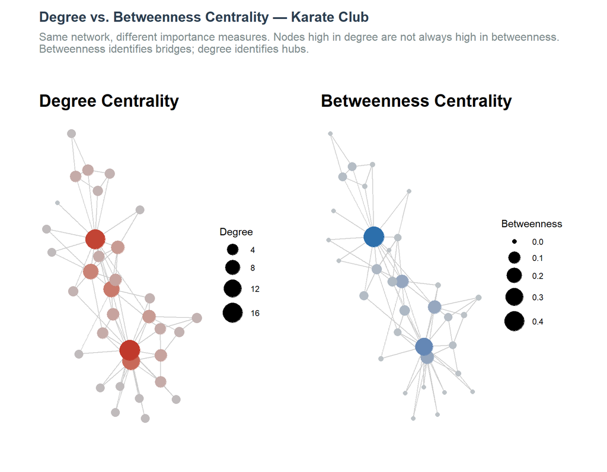

```r
# Visualise all four centrality measures side by side
tg_karate <- as_tbl_graph(karate) |>
  mutate(
    degree      = centrality_degree(),
    betweenness = centrality_betweenness(normalized=TRUE),
    closeness   = centrality_closeness(normalized=TRUE),
    eigenvector = centrality_eigen()
  )

# Create a comparison plot for degree vs betweenness (most contrasting)
p1 <- ggraph(tg_karate, layout="fr") +
  geom_edge_link(colour="grey80", linewidth=0.4) +
  geom_node_point(aes(size=degree, colour=degree)) +
  scale_colour_gradient(low="#BDC3C7", high="#C0392B", guide="none") +
  scale_size_continuous(range=c(2,10), name="Degree") +
  labs(title="Degree Centrality") + theme_graph()

p2 <- ggraph(tg_karate, layout="fr") +
  geom_edge_link(colour="grey80", linewidth=0.4) +
  geom_node_point(aes(size=betweenness, colour=betweenness)) +
  scale_colour_gradient(low="#BDC3C7", high="#2C6FAC", guide="none") +
  scale_size_continuous(range=c(2,10), name="Betweenness") +
  labs(title="Betweenness Centrality") + theme_graph()

library(patchwork)
(p1 + p2) + plot_annotation(
  title    = "Degree vs. Betweenness Centrality — Karate Club",
  subtitle = paste("Same network, different importance measures.",
                   "Nodes high in degree are not always high in betweenness.",
                   "\nBetweenness identifies bridges; degree identifies hubs.")
)
```

**Why degree and betweenness can differ dramatically:** Consider a node on the boundary between two otherwise disconnected clusters. It may have only 3 or 4 connections (low degree) but sit on the only path connecting the two clusters (very high betweenness). This is a structural hole — the broker position Burt (2004) identifies as a source of information advantages.

# 4 Part C: Community Detection

## 4.1 What a Community Is

A community (or cluster, module) is a set of nodes that are more densely connected to each other than to nodes outside the set. Community structure is pervasive in social networks: friend groups, political factions, research communities, departments within organisations.

The standard measure of community quality is **modularity** (Q). It compares the actual density of edges within communities to the expected density if edges were placed at random (preserving degree sequence):

$$Q = \sum_c \left[\frac{L_c}{m} -
\left(\frac{d_c}{2m}\right)^2\right]$$

where $L_c$ = edges within community $c$, $m$ = total edges, $d_c$ = total degree of nodes in $c$. Q ranges from -0.5 to 1.0; values > 0.3 indicate meaningful community structure.

```r
set.seed(2024)

# Three major algorithms
comm_louvain  <- cluster_louvain(karate)        # Fast, good for large networks
comm_walktrap <- cluster_walktrap(karate)        # Based on random walks
comm_greedy   <- cluster_fast_greedy(karate)     # Hierarchical, builds dendrogram

cat("=== Community Detection Comparison ===\n\n")
```

```
## === Community Detection Comparison ===
```

```r
cat("Algorithm         | N communities | Modularity\n")
```

```
## Algorithm         | N communities | Modularity
```

```r
cat("------------------|---------------|----------\n")
```

```
## ------------------|---------------|----------
```

```r
cat("Louvain           |", length(comm_louvain),
    "             |", round(modularity(comm_louvain), 4), "\n")
```

```
## Louvain           | 3              | 0.4345
```

```r
cat("Walktrap          |", length(comm_walktrap),
    "             |", round(modularity(comm_walktrap), 4), "\n")
```

```
## Walktrap          | 4              | 0.4402
```

```r
cat("Fast-greedy       |", length(comm_greedy),
    "             |", round(modularity(comm_greedy), 4), "\n\n")
```

```
## Fast-greedy       | 3              | 0.4345
```

```r
cat("True split (Zachary's observation): 2 factions\n")
```

```
## True split (Zachary's observation): 2 factions
```

```r
cat("Historical faction 1: instructor's followers\n")
```

```
## Historical faction 1: instructor's followers
```

```r
cat("Historical faction 2: administrator's followers\n")
```

```
## Historical faction 2: administrator's followers
```

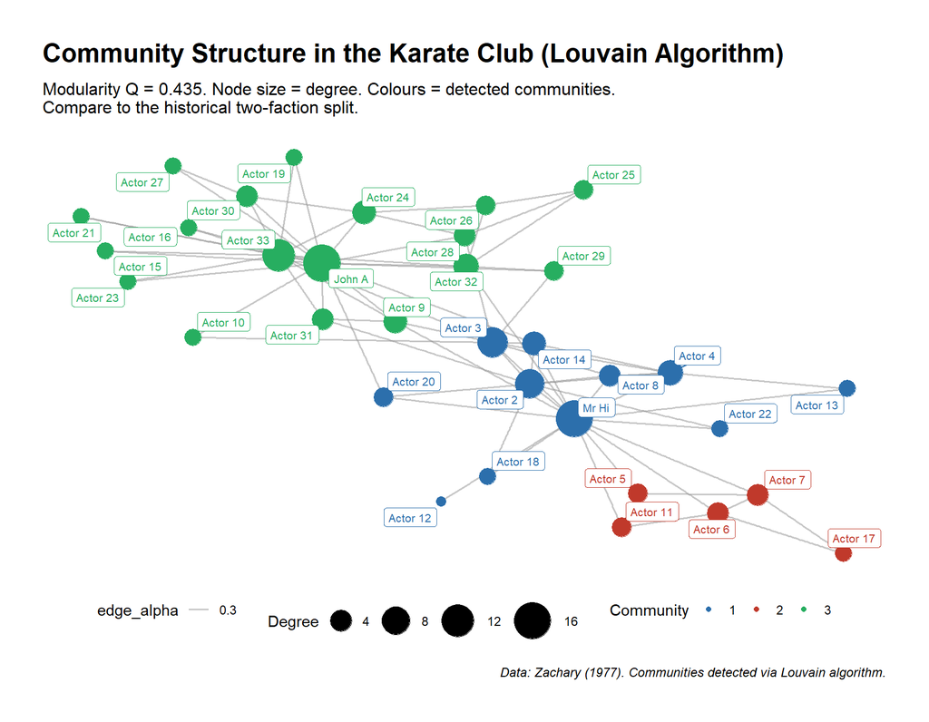

```r
# Visualise the community structure — Louvain result
tg_comm <- as_tbl_graph(karate) |>
  mutate(
    community = factor(membership(comm_louvain)),
    degree    = centrality_degree()
  )

ggraph(tg_comm, layout="fr") +
  geom_edge_link(aes(alpha=0.3), colour="grey60", linewidth=0.6) +
  geom_node_point(aes(colour=community, size=degree)) +
  geom_node_label(aes(label=name, colour=community),
                  repel=TRUE, size=2.8, show.legend=FALSE) +
  scale_colour_manual(values=css_palette(length(unique(membership(comm_louvain)))),
                      name="Community") +
  scale_size_continuous(range=c(3,12), name="Degree") +
  labs(
    title    = "Community Structure in the Karate Club (Louvain Algorithm)",
    subtitle = paste0(
      "Modularity Q = ", round(modularity(comm_louvain), 3),
      ". Node size = degree. Colours = detected communities.",
      "\nCompare to the historical two-faction split."
    ),
    caption  = "Data: Zachary (1977). Communities detected via Louvain algorithm."
  ) +
  theme_graph() +
  theme(legend.position="bottom")
```

**Interpreting community detection output:**

1. **Number of communities:** More communities = finer-grained structure. Compare algorithms — if they all agree on the same partition, the community structure is robust.
2. **Modularity Q:** Higher is better. Q > 0.3 = meaningful structure. Q < 0.1 = weak or absent community structure.
3. **Comparison to ground truth:** When available (as here — Zachary observed the actual split), compare the detected communities to what really happened. Discrepancies reveal where the algorithm fails to capture the social dynamics.

# 5 Part D: Exponential Random Graph Models (ERGM)

## 5.1 Why Standard Regression Fails for Network Data

Network data violates the independence assumption of standard regression in two fundamental ways:

1. **Dyadic dependence:** Whether A is connected to B is not independent of whether B is connected to C, which is not independent of whether A is connected to C. Ties are interdependent by definition.
2. **Reciprocity:** In directed networks, A→B is not independent of B→A — people tend to return relationships.

The consequence: treating each tie as an independent observation (which logistic regression would do) produces severely biased standard errors. Tests are wrong; everything is wrong.

**Exponential Random Graph Models (ERGMs)** solve this by modelling the *entire network* as a single observation from a probability distribution over all possible networks with the same nodes. The model specifies which network configurations (triangles, reciprocated ties, ties between similar nodes) are more or less probable than chance.

## 5.2 The Florentine Marriage Network

We use the classic Padgett & Ansell (1993) dataset: 16 elite Florentine families, connected by marriage alliances in the 15th century. Medici was the most politically powerful family. The question: was their rise due to their wealth, or to their structural position in the marriage network?

```r
library(ergm)
library(network)

data("florentine")   # The Florentine family marriage network (network object)
flo <- flomarriage   # alias for convenience

cat("=== Florentine Marriage Network ===\n")
```

```
## === Florentine Marriage Network ===
```

```r
cat("Families (nodes):", network.size(flo), "\n")
```

```
## Families (nodes): 16
```

```r
cat("Marriage ties (edges):", network.edgecount(flo), "\n")
```

```
## Marriage ties (edges): 20
```

```r
cat("Directed:", network::is.directed(flo), "(undirected — marriage is mutual)\n\n")
```

```
## Directed: FALSE (undirected — marriage is mutual)
```

```r
# The wealth attribute: estimated wealth of each family
cat("Family wealth (in thousands of lire):\n")
```

```
## Family wealth (in thousands of lire):
```

```r
flo %v% "wealth" |> sort(decreasing=TRUE) |> head(8) |> print()
```

```
## [1] 146 103  55  49  48  48  44  42
```

```r
cat("Medici wealth rank:", rank(-(flo %v% "wealth"))[network.vertex.names(flo)=="Medici"], "\n")
```

```
## Medici wealth rank: 2
```

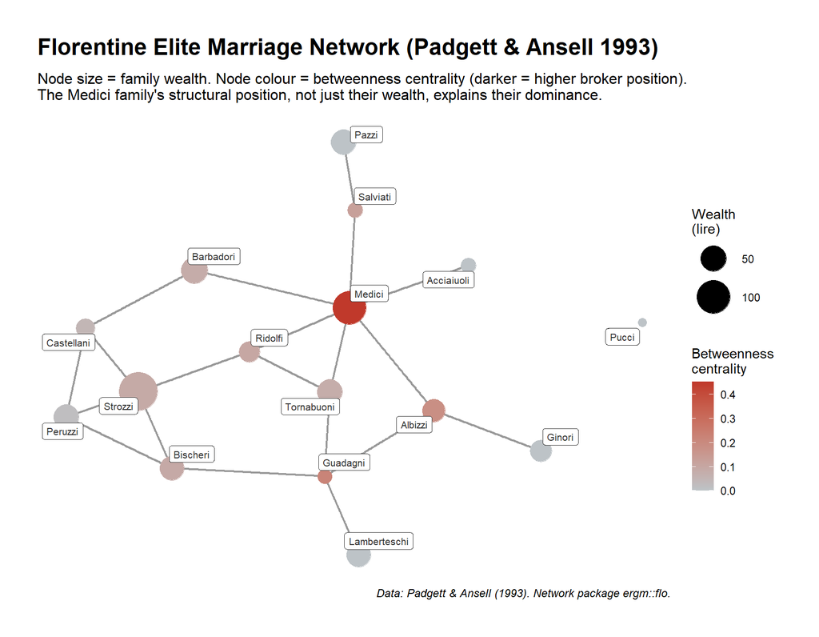

```r
# Convert to igraph for ggraph visualisation
g_flo <- graph_from_adjacency_matrix(
  as.matrix(flo),
  mode="undirected"
)
V(g_flo)$name   <- network.vertex.names(flo)
V(g_flo)$wealth <- flo %v% "wealth"

tg_flo <- as_tbl_graph(g_flo) |>
  mutate(degree=centrality_degree(),
         between=centrality_betweenness(normalized=TRUE))

ggraph(tg_flo, layout="fr") +
  geom_edge_link(colour="grey60", linewidth=0.8) +
  geom_node_point(aes(size=wealth, colour=between)) +
  scale_colour_gradient(low="#BDC3C7", high="#C0392B",
                        name="Betweenness\ncentrality") +
  scale_size_continuous(range=c(3,14), name="Wealth\n(lire)") +
  geom_node_label(aes(label=name), repel=TRUE, size=2.8, colour="grey20") +
  labs(
    title    = "Florentine Elite Marriage Network (Padgett & Ansell 1993)",
    subtitle = paste("Node size = family wealth.",
                     "Node colour = betweenness centrality (darker = higher broker position).",
                     "\nThe Medici family's structural position, not just their wealth, explains their dominance."),
    caption  = "Data: Padgett & Ansell (1993). Network package ergm::flo."
  ) +
  theme_graph() + theme(legend.position="right")
```

## 5.3 Fitting ERGMs — Normal Workflow

We fit a sequence of models of increasing complexity, starting with the simplest possible model (edges only) and adding structural and attribute terms one at a time.

```r
set.seed(2024)

# MODEL 1: Edges only (the null model)
# This estimates the probability that any pair of families is married
# analogous to an intercept-only logistic regression
m1 <- ergm(flo ~ edges, control=control.ergm(seed=42))

cat("=== MODEL 1: Edges only ===\n")
```

```
## === MODEL 1: Edges only ===
```

```r
summary(m1)
```

```
## Call:
## ergm(formula = flo ~ edges, control = control.ergm(seed = 42))
##
## Maximum Likelihood Results:
##
##       Estimate Std. Error MCMC % z value Pr(>|z|)
## edges  -1.6094     0.2449      0  -6.571   <1e-04 ***
## ---
## Signif. codes:  0 '***' 0.001 '**' 0.01 '*' 0.05 '.' 0.1 ' ' 1
##
##      Null Deviance: 166.4  on 120  degrees of freedom
##  Residual Deviance: 108.1  on 119  degrees of freedom
##
## AIC: 110.1  BIC: 112.9  (Smaller is better. MC Std. Err. = 0)
```

```r
cat("\n=== READING THE ERGM OUTPUT (Model 1) ===\n\n")
```

```
##
## === READING THE ERGM OUTPUT (Model 1) ===
```

```r
coef_m1 <- coef(m1)
cat("Coefficient (edges):", round(coef_m1["edges"], 4), "\n")
```

```
## Coefficient (edges): -1.6094
```

```r
cat("Log-odds that any given pair is connected:", round(coef_m1["edges"], 4), "\n")
```

```
## Log-odds that any given pair is connected: -1.6094
```

```r
cat("Probability of any tie:", round(plogis(coef_m1["edges"]), 4), "\n\n")
```

```
## Probability of any tie: 0.1667
```

```r
cat("Cross-check: observed density =",
    round(network.edgecount(flo) / (network.size(flo)*(network.size(flo)-1)/2), 4),
    "\n")
```

```
## Cross-check: observed density = 0.1667
```

```r
cat("These match: the edges term IS the baseline tie probability.\n")
```

```
## These match: the edges term IS the baseline tie probability.
```

```r
# MODEL 2: Edges + triangle (endogenous social structure)
# Triangles: do families that share a mutual friend tend to marry?
# This is the network analogue of transitivity
m2 <- ergm(flo ~ edges + triangle,
           control=control.ergm(seed=42, MCMLE.maxit=30))
cat("=== MODEL 2: Edges + triangle ===\n")
```

```
## === MODEL 2: Edges + triangle ===
```

```r
summary(m2)
```

```
## Call:
## ergm(formula = flo ~ edges + triangle, control = control.ergm(seed = 42,
##     MCMLE.maxit = 30))
##
## Monte Carlo Maximum Likelihood Results:
##
##          Estimate Std. Error MCMC % z value Pr(>|z|)
## edges     -1.6507     0.3179      0  -5.192   <1e-04 ***
## triangle   0.1082     0.5184      0   0.209    0.835
## ---
## Signif. codes:  0 '***' 0.001 '**' 0.01 '*' 0.05 '.' 0.1 ' ' 1
##
##      Null Deviance: 166.4  on 120  degrees of freedom
##  Residual Deviance: 108.1  on 118  degrees of freedom
##
## AIC: 112.1  BIC: 117.7  (Smaller is better. MC Std. Err. = 0.006221)
```

```r
# MODEL 3: Edges + nodecov(wealth) (attribute effect)
# Do wealthier families marry more? (degree ~ wealth correlation)
m3 <- ergm(flo ~ edges + nodecov("wealth"),
           control=control.ergm(seed=42))
cat("\n=== MODEL 3: Edges + wealth (main effect) ===\n")
```

```
##
## === MODEL 3: Edges + wealth (main effect) ===
```

```r
summary(m3)
```

```
## Call:
## ergm(formula = flo ~ edges + nodecov("wealth"), control = control.ergm(seed = 42))
##
## Maximum Likelihood Results:
##
##                 Estimate Std. Error MCMC % z value Pr(>|z|)
## edges          -2.594929   0.536056      0  -4.841   <1e-04 ***
## nodecov.wealth  0.010546   0.004674      0   2.256   0.0241 *
## ---
## Signif. codes:  0 '***' 0.001 '**' 0.01 '*' 0.05 '.' 0.1 ' ' 1
##
##      Null Deviance: 166.4  on 120  degrees of freedom
##  Residual Deviance: 103.1  on 118  degrees of freedom
##
## AIC: 107.1  BIC: 112.7  (Smaller is better. MC Std. Err. = 0)
```

```r
# MODEL 4: Full model — edges + triangles + wealth
m4 <- ergm(flo ~ edges + triangle + nodecov("wealth"),
           control=control.ergm(seed=42, MCMLE.maxit=30))
cat("\n=== MODEL 4: Full model ===\n")
```

```
##
## === MODEL 4: Full model ===
```

```r
summary(m4)
```

```
## Call:
## ergm(formula = flo ~ edges + triangle + nodecov("wealth"), control = control.ergm(seed = 42,
##     MCMLE.maxit = 30))
##
## Monte Carlo Maximum Likelihood Results:
##
##                 Estimate Std. Error MCMC % z value Pr(>|z|)
## edges          -2.549536   0.527531      0  -4.833   <1e-04 ***
## triangle       -0.062519   0.570834      0  -0.110   0.9128
## nodecov.wealth  0.010554   0.005133      0   2.056   0.0398 *
## ---
## Signif. codes:  0 '***' 0.001 '**' 0.01 '*' 0.05 '.' 0.1 ' ' 1
##
##      Null Deviance: 166.4  on 120  degrees of freedom
##  Residual Deviance: 103.1  on 117  degrees of freedom
##
## AIC: 109.1  BIC: 117.5  (Smaller is better. MC Std. Err. = 0.005862)
```

## 5.4 Reading the Full ERGM Output

Complete Guide to ERGM Summary Output

[output not shown]

## 5.5 Interpreting ERGM Coefficients

```r
cat("=== MODEL 4 COEFFICIENT INTERPRETATION ===\n\n")
```

```
## === MODEL 4 COEFFICIENT INTERPRETATION ===
```

```r
coefs <- coef(m4)

cat("EDGES term:", round(coefs["edges"],3), "\n")
```

```
## EDGES term: -2.55
```

```r
cat("  Baseline log-odds of any tie:", round(coefs["edges"],3), "\n")
```

```
##   Baseline log-odds of any tie: -2.55
```

```r
cat("  Baseline probability:", round(plogis(coefs["edges"]),3), "\n\n")
```

```
##   Baseline probability: 0.072
```

```r
cat("TRIANGLE term:", round(coefs["triangle"],3), "\n")
```

```
## TRIANGLE term: -0.063
```

```r
cat("  A positive value means: a tie is MORE likely if it would close a triangle.\n")
```

```
##   A positive value means: a tie is MORE likely if it would close a triangle.
```

```r
cat("  Interpretation: there is ", ifelse(coefs["triangle"]>0,"positive","negative"),
    "triadic closure in this network.\n")
```

```
##   Interpretation: there is  negative triadic closure in this network.
```

```r
cat("  Families that share existing marriage allies tend",
    ifelse(coefs["triangle"]>0,"to also marry each other.\n",
           "NOT to marry each other.\n"), "\n")
```

```
##   Families that share existing marriage allies tend NOT to marry each other.
##
```

```r
cat("NODECOV(wealth):", round(coefs["nodecov.wealth"],3), "\n")
```

```
## NODECOV(wealth): 0.011
```

```r
cat("  Interpretation: for each additional unit of wealth,\n")
```

```
##   Interpretation: for each additional unit of wealth,
```

```r
cat("  the log-odds of forming a tie increase by",
    round(coefs["nodecov.wealth"],4), "\n")
```

```
##   the log-odds of forming a tie increase by 0.0106
```

```r
cat("  The odds ratio:", round(exp(coefs["nodecov.wealth"]),4), "\n")
```

```
##   The odds ratio: 1.0106
```

```r
cat("  Wealthier families are", ifelse(coefs["nodecov.wealth"]>0,"more","less"),
    "likely to form marriage ties.\n")
```

```
##   Wealthier families are more likely to form marriage ties.
```

## 5.6 Model Diagnostics

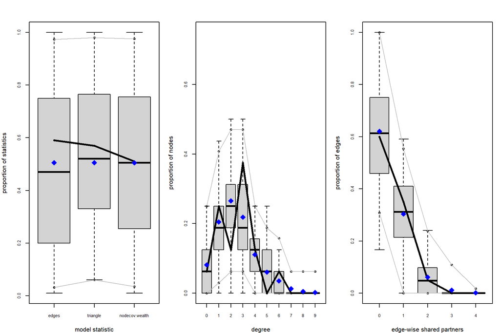

```r
# Goodness of fit: does the model reproduce key network statistics?
# Compare observed network to 100 networks simulated from the fitted model
gof_m4 <- gof(m4)

old_par <- par(mfrow=c(1,3), mar=c(4,4,3,1))
plot(gof_m4)
```

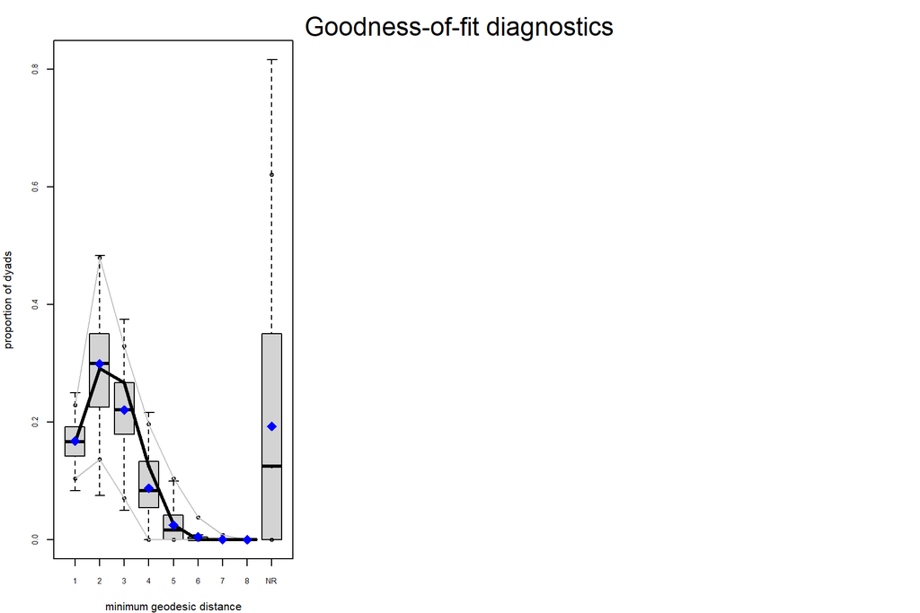

```r
par(old_par)
```

The three standard GOF statistics: - **Degree distribution:** Does the model reproduce how many high-degree and low-degree nodes there are? - **Edge-wise shared partners:** Does the model reproduce clustering patterns? - **Minimum geodesic distance:** Does the model reproduce path length distribution?

```r
# Model comparison table
cat("=== MODEL COMPARISON ===\n\n")
```

```
## === MODEL COMPARISON ===
```

```r
tibble(
  Model = c("M1: Edges only","M2: + triangle","M3: + wealth","M4: Full"),
  AIC   = round(c(AIC(m1),AIC(m2),AIC(m3),AIC(m4)),2),
  BIC   = round(c(BIC(m1),BIC(m2),BIC(m3),BIC(m4)),2),
  LogLik= round(c(logLik(m1),logLik(m2),logLik(m3),logLik(m4)),2)
) |>
  kbl(caption="ERGM Model Comparison") |>
  kable_styling(bootstrap_options=c("striped","hover")) |>
  row_spec(which.min(c(AIC(m1),AIC(m2),AIC(m3),AIC(m4))),
           bold=TRUE, background="#EAFAF1") |>
  footnote(general=paste(
    "Lower AIC/BIC = better fit. Bold/green row = best-fitting model.",
    "\nThe full model (M4) should fit best if both structure and wealth matter."
  ))
```

ERGM Model Comparison

| Model | AIC | BIC | LogLik |
| --- | --- | --- | --- |
| M1: Edges only | 110.13 | 112.92 | -54.07 |
| M2: + triangle | 112.08 | 117.66 | -54.04 |
| M3: + wealth | 107.11 | 112.68 | -51.55 |
| M4: Full | 109.09 | 117.45 | -51.55 |

Note:  
Lower AIC/BIC = better fit. Bold/green row = best-fitting model. The full model (M4) should fit best if both structure and wealth matter.

# 6 Part E: A Complete Network Analysis Workflow

```r
cat("COMPLETE NETWORK ANALYSIS WORKFLOW\n")
```

```
## COMPLETE NETWORK ANALYSIS WORKFLOW
```

```r
cat("====================================\n\n")
cat("STEP 1: Define the network boundary\n")
```

[output not shown]

```r
cat("   Who/what are the nodes? What counts as an edge?\n")
```

```
##    Who/what are the nodes? What counts as an edge?
```

```r
cat("   Karate club: 34 members; edges = socialised outside club\n\n")
```

```
##    Karate club: 34 members; edges = socialised outside club
```

```r
cat("STEP 2: Gather data and build the graph object\n")
```

```
## STEP 2: Gather data and build the graph object
```

```r
cat("   Edge list → graph_from_data_frame()\n")
```

```
##    Edge list → graph_from_data_frame()
```

```r
cat("   Adjacency matrix → graph_from_adjacency_matrix()\n")
```

```
##    Adjacency matrix → graph_from_adjacency_matrix()
```

```r
cat("   Attribute data → V(g)$name <- ...\n\n")
```

```
##    Attribute data → V(g)$name <- ...
```

```r
cat("STEP 3: Describe the overall structure\n")
```

```
## STEP 3: Describe the overall structure
```

```r
cat("   edge_density(), mean_distance(), diameter(), transitivity()\n")
```

```
##    edge_density(), mean_distance(), diameter(), transitivity()
```

```r
cat("   Check: how many components? Is the largest component big enough?\n\n")
```

```
##    Check: how many components? Is the largest component big enough?
```

```r
cat("STEP 4: Compute centrality\n")
```

```
## STEP 4: Compute centrality
```

```r
cat("   degree(), betweenness(), closeness(), eigen_centrality()\n")
```

```
##    degree(), betweenness(), closeness(), eigen_centrality()
```

```r
cat("   Normalise: normalized=TRUE\n")
```

```
##    Normalise: normalized=TRUE
```

```r
cat("   Ask: which measure fits my research question?\n\n")
```

```
##    Ask: which measure fits my research question?
```

```r
cat("STEP 5: Detect communities (if relevant)\n")
```

```
## STEP 5: Detect communities (if relevant)
```

```r
cat("   cluster_louvain(), cluster_walktrap()\n")
```

```
##    cluster_louvain(), cluster_walktrap()
```

```r
cat("   Report: modularity, number of communities, validation against ground truth\n\n")
```

```
##    Report: modularity, number of communities, validation against ground truth
```

```r
cat("STEP 6: Statistical modelling (ERGM)\n")
```

```
## STEP 6: Statistical modelling (ERGM)
```

```r
cat("   Start with edges-only null model\n")
```

```
##    Start with edges-only null model
```

```r
cat("   Add structural terms: triangle, gwesp, gwdegree\n")
```

```
##    Add structural terms: triangle, gwesp, gwdegree
```

```r
cat("   Add attribute terms: nodecov, nodematch, absdiff\n")
```

```
##    Add attribute terms: nodecov, nodematch, absdiff
```

```r
cat("   Compare models with AIC/BIC; validate with gof()\n\n")
```

```
##    Compare models with AIC/BIC; validate with gof()
```

```r
cat("STEP 7: Visualise meaningfully\n")
```

```
## STEP 7: Visualise meaningfully
```

```r
cat("   ggraph() with informative node/edge aesthetics\n")
```

```
##    ggraph() with informative node/edge aesthetics
```

```r
cat("   Size = centrality; colour = community or attribute\n")
```

```
##    Size = centrality; colour = community or attribute
```

```r
cat("   Always use a reproducible layout seed\n")
```

```
##    Always use a reproducible layout seed
```

# 7 Common Mistakes

| Mistake | Consequence | Prevention |
| --- | --- | --- |
| Using logistic regression on dyadic data | Biased SEs; invalid p-values | Use ERGM for binary network outcomes |
| Treating all centrality measures as interchangeable | Misidentifying who matters | Choose centrality based on the substantive process |
| Not checking GOF after ERGM | Unknown whether model fits the data | Always run gof() and inspect the plots |
| Not setting a seed for community detection | Non-reproducible results | Always set.seed() before stochastic algorithms |
| Ignoring isolates (nodes with degree 0) | Biased density and other statistics | Note isolates; decide whether to include or exclude with justification |
| Claiming causal direction from a network correlation | Edge between node attributes ≠ causal | Use longitudinal network data (SIENA/stochastic actor model) for causal claims |

# 8 Check Your Understanding

**1.** Create a directed network from this description: Alice follows Bob and Carol; Bob follows Alice and Dan; Carol follows Dan; Dan follows Bob. (a) Build the igraph object. (b) Compute in-degree and out-degree for each node. (c) Who has highest betweenness? (d) Draw the network.

**2.** In the karate club network, nodes 1 and 34 have high degree. Do they also have high betweenness? What does the comparison tell you about their structural roles?

**3.** Run `gof()` on ERGM Model 1 (edges only). Which network statistics does this null model fail to reproduce? Add the triangle term (Model 2) and run `gof()` again. Which statistics improve?

**4.** In ERGM Model 4, the `nodecov("wealth")` coefficient is positive. Translate this into a substantive claim about Florentine elite marriage behaviour. What would a negative coefficient mean?

**5.** 🟥 Burt (2004) argues that nodes in structural hole positions (high betweenness, bridging disconnected groups) have information and control advantages. Using the karate club network, identify two nodes that might be structural holes. Describe in sociological terms what advantage their position confers, and why the other members of their respective communities might not have detected the impending split.

```r
sessionInfo()
## R version 4.5.3 (2026-03-11 ucrt)
## Platform: x86_64-w64-mingw32/x64
## Running under: Windows 11 x64 (build 26200)
##
## Matrix products: default
##   LAPACK version 3.12.1
##
## locale:
## [1] LC_COLLATE=English_Israel.utf8  LC_CTYPE=English_Israel.utf8
## [3] LC_MONETARY=English_Israel.utf8 LC_NUMERIC=C
## [5] LC_TIME=English_Israel.utf8
##
## time zone: Asia/Jerusalem
## tzcode source: internal
##
## attached base packages:
## [1] stats     graphics  grDevices utils     datasets  methods   base
##
## other attached packages:
##  [1] patchwork_1.3.2           ergm_4.12.0
##  [3] network_1.20.0            tidygraph_1.3.1
##  [5] ggraph_2.2.2              igraph_2.2.2
##  [7] topicmodels_0.2-17        tidytext_0.4.3
##  [9] quanteda.textplots_0.96.1 quanteda.textstats_0.97.2
## [11] quanteda_4.3.1            factoextra_2.0.0
## [13] tidyLPA_2.0.2             tidySEM_0.2.10
## [15] poLCA_1.6.0.2             MASS_7.3-65
## [17] scatterplot3d_0.3-45      gssr_0.9
## [19] fixest_0.14.0             MatchIt_4.7.2
## [21] ggdag_0.2.13              dagitty_0.3-4
## [23] kableExtra_1.4.0          lubridate_1.9.5
## [25] forcats_1.0.1             stringr_1.6.0
## [27] dplyr_1.2.0               readr_2.2.0
## [29] tidyr_1.3.2               tidyverse_2.0.0
## [31] GPArotation_2025.3-1      semTools_0.5-8
## [33] semPlot_1.1.8             lavaan_0.6-21
## [35] psych_2.6.3               purrr_1.2.1
## [37] tibble_3.3.1              ggplot2_4.0.2
## [39] rmarkdown_2.31
##
## loaded via a namespace (and not attached):
##   [1] fs_2.0.1                 httr_1.4.8               RColorBrewer_1.1-3
##   [4] repr_1.1.7               numDeriv_2016.8-1.1      tools_4.5.3
##   [7] backports_1.5.0          utf8_1.2.6               R6_2.6.1
##  [10] mgcv_1.9-4               withr_3.0.2              prettyunits_1.2.0
##  [13] gridExtra_2.3            nonnest2_0.5-9           fdrtool_1.2.18
##  [16] progressr_0.19.0         qgraph_1.9.8             cli_3.6.5
##  [19] textshaping_1.0.5        fastDummies_1.7.5        sandwich_3.1-1
##  [22] labeling_0.4.3           slam_0.1-55              sass_0.4.10
##  [25] robustbase_0.99-7        mvtnorm_1.3-6            S7_0.2.1
##  [28] tm_0.7-18                pbapply_1.7-4            pbivnorm_0.6.0
##  [31] systemfonts_1.3.2        foreign_0.8-91           dbscan_1.2.4
##  [34] svglite_2.2.2            parallelly_1.46.1        lisrelToR_0.3
##  [37] rstudioapi_0.18.0        generics_0.1.4           gtools_3.9.5
##  [40] car_3.1-5                zip_2.3.3                OpenMx_2.22.11
##  [43] Matrix_1.7-4             abind_1.4-8              lifecycle_1.0.5
##  [46] multcomp_1.4-30          yaml_2.3.12              CompQuadForm_1.4.4
##  [49] carData_3.0-6            grid_4.5.3               crayon_1.5.3
##  [52] lattice_0.22-9           haven_2.5.5              lpSolveAPI_5.5.2.0-17.15
##  [55] pillar_1.11.1            knitr_1.51               boot_1.3-32
##  [58] estimability_1.5.1       corpcor_1.6.10           future.apply_1.20.2
##  [61] stopwords_2.3            codetools_0.2-20         fastmatch_1.1-8
##  [64] glue_1.8.0               V8_8.0.1                 data.table_1.18.2.1
##  [67] vctrs_0.7.2              png_0.1-9                Rdpack_2.6.6
##  [70] gtable_0.3.6             gsubfn_0.7               cachem_1.1.0
##  [73] xfun_0.57                openxlsx_4.2.8.1         rbibutils_2.4.1
##  [76] coda_0.19-4.1            reformulas_0.4.4         survival_3.8-6
##  [79] MplusAutomation_1.2      TH.data_1.1-5            nlme_3.1-168
##  [82] progress_1.2.3           dreamerr_1.5.0           rprojroot_2.1.1
##  [85] mi_1.2                   SnowballC_0.7.1          bslib_0.10.0
##  [88] stringmagic_1.2.0        otel_0.2.0               rpart_4.1.24
##  [91] colorspace_2.1-2         Hmisc_5.2-5              nnet_7.3-20
##  [94] mnormt_2.1.2             tidyselect_1.2.1         emmeans_2.0.2
##  [97] compiler_4.5.3           curl_7.0.0               htmlTable_2.4.3
## [100] xml2_1.5.2               NLP_0.3-2                checkmate_2.3.4
## [103] scales_1.4.0             DEoptimR_1.1-4           quadprog_1.5-8
## [106] sem_3.1-16               digest_0.6.39            minqa_1.2.8
## [109] htmltools_0.5.9          pkgconfig_2.0.3          jpeg_0.1-11
## [112] base64enc_0.1-6          lme4_2.0-1               fastmap_1.2.0
## [115] rlang_1.1.7              htmlwidgets_1.6.4        farver_2.1.2
## [118] jquerylib_0.1.4          zoo_1.8-15               jsonlite_2.0.0
## [121] mclust_6.1.2             statnet.common_4.13.0    tokenizers_0.3.0
## [124] magrittr_2.0.4           modeltools_0.2-24        Formula_1.2-5
## [127] texreg_1.39.5            Rcpp_1.1.1               viridis_0.6.5
## [130] proto_1.0.0              rockchalk_1.8.157        stringi_1.8.7
## [133] chk_0.10.0               plyr_1.8.9               parallel_4.5.3
## [136] listenv_0.10.1           ggrepel_0.9.8            kutils_1.73
## [139] graphlayouts_1.2.3       splines_4.5.3            pander_0.6.6
## [142] hms_1.1.4                reshape2_1.4.5           stats4_4.5.3
## [145] rle_0.10.0               XML_3.99-0.23            evaluate_1.0.5
## [148] trust_0.1-9              RcppParallel_5.1.11-2    nloptr_2.2.1
## [151] tzdb_0.5.0               tweenr_2.0.3             RANN_2.6.2
## [154] polyclip_1.10-7          future_1.70.0            ggforce_0.5.0
## [157] skimr_2.2.2              broom_1.0.12             xtable_1.8-8
## [160] janeaustenr_1.0.0        glasso_1.11              viridisLite_0.4.3
## [163] nsyllable_1.0.1          arm_1.15-2               memoise_2.0.1
## [166] cluster_2.1.8.2          timechange_0.4.0         globals_0.19.1
## [169] here_1.0.2
```